# Campus Study Habits: A Visual Observation Story

## Exploring Campus Study Environments

This visual story explores how students at the University of Auckland utilize campus study spaces across different stages of the semester. The data was collected through manual observations of desks, noting device types, the presence of non-electronic study materials, and the general “vibe” of the environment. By looking at three distinct sessions, we can see how study habits evolve as the semester progresses.

## Device Usage and Desk Clutter Trends

Our first visualization explores the relationship between the type of device being used and the amount of “analog” clutter (non-electronic items like textbooks, notebooks, and snacks) on the desk.

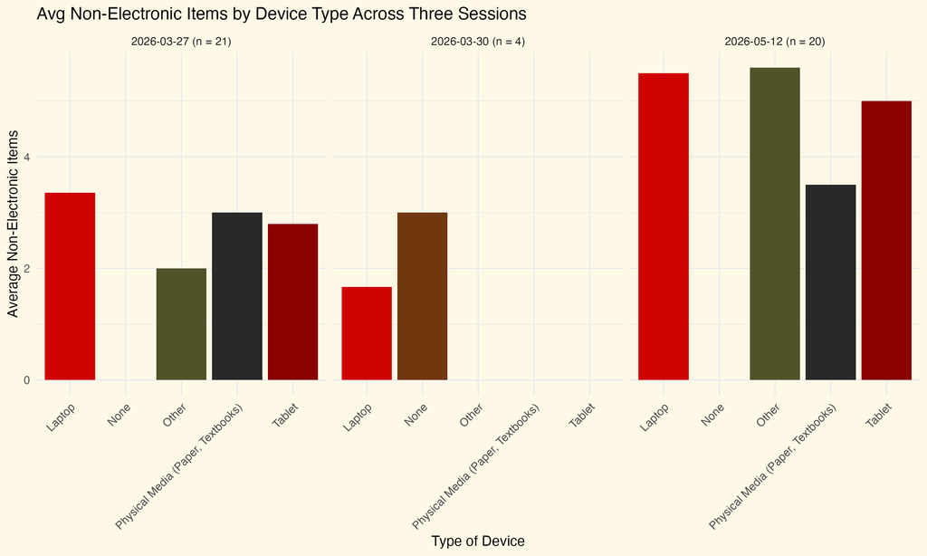

A faceted bar chart showing average non-electronic items by device type across three recording sessions. Laptops and tablets are the primary devices, with non-electronic items showing variation over time.

As seen in the chart, the complexity of a student’s desk setup often changes depending on the session, reflecting the shift from early-semester reading to late-semester assignment and test preparation. This variance in clutter could also be attributed to shifts in location, for example during one particular session of data collection in the Engineering building, engineering students may have had a test in the evening resulting in a more cluttered study space than usual. However, this cannot be assumed by the data we have collected.

## Where Students Choose to Study

Students have diverse preferences for their study environments, ranging from silent library zones to social collaborative areas. The following boxplot illustrates the distribution of non-electronic items across these different campus environments, highlighting where the most intensive study sessions occur.

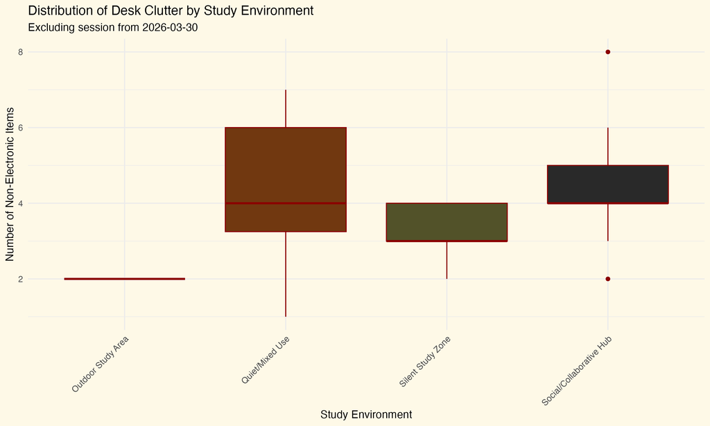

A boxplot showing the distribution of non-electronic items on desks across various campus study environments like Silent Study Zones and Social Hubs. Quiet and mixed zones often show higher variation in physical study materials.

## The ‘Vibe’ of Campus Focus

Finally, we categorized campus locations into two primary groupings: **Social** and **Individual**. We can see how device choice shifts depending on the social atmosphere of the room.

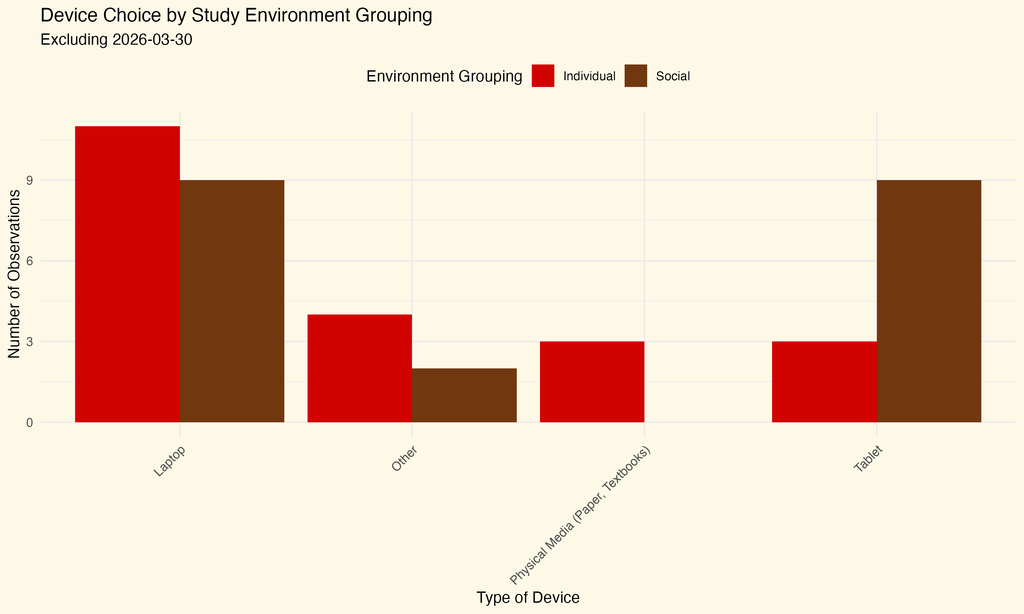